← Back to the hackathon home

Topic 12 of 18

# DHIS2 Data Visualizer

Step by Step Guide: Building Pivot Tables and Charts, Using ANC Visits as the Example

**Purpose of this guide**

Data that has been entered is of no use until somebody looks at it. This guide builds a pivot table and then every kind of chart from the same selection, so you can see what each one is good for. It uses the four ANC visit data elements, because they hold data in every demo, and the steps are identical for your own malaria data elements and indicators. The charts you save here are what the next topic puts on a dashboard.

Step 1: Open the Data Visualizer

Charts and pivot tables are built in the **Data Visualizer**. Open the apps menu and pick it from the list, or type the first letters of the name.

Click: Apps menu → Data Visualizer

[figure not shown]

1234

**Figure 1.** Finding the app.

1. 1**Search apps.** Type visual to shorten the list.
2. 2**Data Visualizer.** Charts, pivot tables and single values. This guide uses it.
3. 3**Maps.** The same kind of work, on a map.
4. 4**Dashboard.** Where the finished charts are placed, which is the next topic.

Step 2: Know the Workspace

The app opens on an empty pivot table. Everything you build is made of three things: the type of visualisation, the dimensions you pick, and where you put them.

[figure not shown]

12345678

**Figure 2.** The workspace.

1. 1**Visualisation type.** Pivot table to start with. Every chart type sits behind this menu.
2. 2**Update.** Draws the visualisation with the choices you have made. Nothing appears until you click it.
3. 3**Columns.** What runs across the top.
4. 4**Rows.** What runs down the side.
5. 5**Filter.** What the whole visualisation is limited to, without showing it.
6. 6**Data.** The data elements, indicators and data sets you want to see.
7. 7**Period.** Which months or years.
8. 8**Organisation unit.** Which facilities, districts or the whole country.

Step 3: Choose the Data

Click **Data** in the left list. Choose the type on the left of the window, for example Data elements or Indicators, then move the items you want to the right hand list and click Update. This guide uses the four ANC visit data elements as its example, because they exist in every demo.

Click: Data → Data elements → ANC 1st visit, ANC 2nd visit, ANC 3rd visit, ANC 4th or more visits → Update

**For your own work:** pick the malaria data elements you created, or the indicators from Topic 6. The steps are exactly the same whichever you choose.

Step 4: Choose the Organisation Unit

Click **Organisation unit**. You can tick units in the tree, or choose a whole level or group, which is usually what you want for a chart.

[figure not shown]

123456

**Figure 3.** The organisation unit window.

1. 1**User organisation unit.** Whatever the person opening the chart is attached to. Useful for a chart that many people share.
2. 2**User sub units.** The units one level below that person.
3. 3**The tree.** Tick a district or a facility by hand.
4. 4**Select a level.** Every unit at one level, for example every district.
5. 5**Select a group.** Every unit in a group, for example every CHC.
6. 6**Update.** Applies the choice and redraws.

[figure not shown]

123

**Figure 4.** Choosing a level.

1. 1**Select a level.** The list of levels in the hierarchy.
2. 2**District.** Gives one line, bar or row per district.
3. 3**Chiefdom and Facility.** The same idea, further down. Use them with care, as a facility chart can hold hundreds of lines.

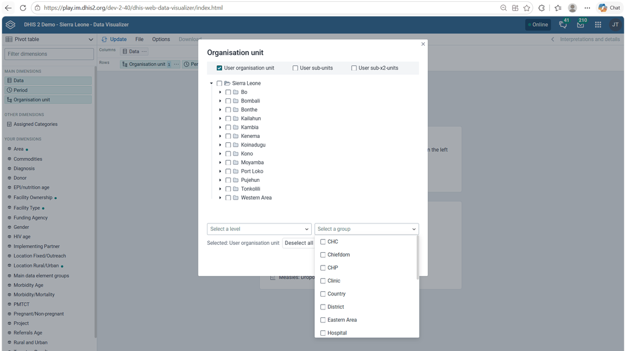

123

**Figure 5.** Choosing a group.

1. 1**Select a group.** Organisation unit groups, such as the type of facility.
2. 2**CHC.** Every community health centre.
3. 3**District.** Groups and levels can be combined, for example every CHC in one district.

[figure not shown]

123

**Figure 6.** One unit chosen.

1. 1**The tick.** Sierra Leone is selected, so the chart shows the whole country as one line.
2. 2**Sierra Leone.** Click a name to tick it, click again to untick it.
3. 3**Selected.** The line under the tree always says what is chosen.

Step 5: Choose the Period

Click **Period**. Relative periods move with time, which is what a dashboard needs, and fixed periods stay where they are, which suits a report about one month.

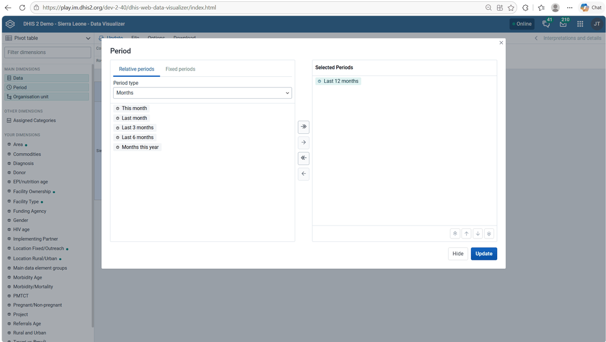

123456

**Figure 7.** Choosing the period.

1. 1**Relative periods.** Last 12 months, this year, last quarter. The chart updates itself every month.
2. 2**Fixed periods.** A named month or year, such as September 2026.
3. 3**Period type.** Months, quarters or years.
4. 4**The list.** Click an item to move it to the right.
5. 5**Selected periods.** What the chart will use.
6. 6**Update.** Applies the choice.

**Rule of thumb:** use Last 12 months for a trend on a dashboard, so nobody has to edit the chart next year.

Step 6: Click Update and Read the Table

With data, period and organisation unit chosen, click **Update**. The pivot table appears, and it is worth reading before drawing any chart, because it shows exactly the numbers the chart will use.

[figure not shown]

12345

**Figure 8.** The numbers behind the chart.

1. 1**Data in Columns.** The four data elements run across the top.
2. 2**Organisation unit and Period in Rows.** The country and the twelve months run down the side.
3. 3**Column headings.** One per data element.
4. 4**The months.** September 2025 to August 2026, from Last 12 months.
5. 5**The values.** The same numbers every chart below is drawn from.

Step 7: Switch to a Chart

Open the visualisation type menu at the top left. Each type suits a different question, and the description under each name says what it is for.

[figure not shown]

12345

**Figure 9.** The visualisation types.

1. 1**The menu.** Click the name at the top left to open it.
2. 2**Pivot table.** The numbers themselves.
3. 3**Column and bar.** Comparing sizes.
4. 4**Line and area.** Change over time.
5. 5**Open as Map.** Sends the same selection to the Maps app.

Step 8: Change Over Time: Line and Area

[figure not shown]

**Figure 10.** Line, one line per data element.

[figure not shown]

**Use a line** when the shape of the trend matters, and **an area** when the total matters as much as the parts.

Step 9: Comparing Sizes: Column and Bar

Columns stand up and bars lie down. They carry the same information, so the choice is about the labels: long names read better on a bar chart.

[figure not shown]

**Figure 12.** Column, months across the bottom.

[figure not shown]

**Figure 13.** Bar, the same data with the labels on the left.

**Rule of thumb:** more than about eight labels, or long names such as facility names, read better as bars.

Step 10: Parts of a Whole: Stacked Charts and Pie

Stacked charts show the parts and the total at the same time. A pie chart shows the shares at one point in time, so the period usually goes in the filter.

[figure not shown]

**Figure 14.** Stacked column, the total and the parts.

[figure not shown]

**Figure 15.** Stacked bar, the same idea lying down.

[figure not shown]

**Figure 16.** Pie, the share of each over the whole period.

**Keep pies small:** four or five slices at most. Beyond that, a bar chart is easier to read.

Step 11: Compare Years: Year Over Year

Year over year puts this year against last year on the same twelve months, which is the quickest way to see whether a season is worse than usual.

[figure not shown]

123

**Figure 17.** Year over year, as lines.

1. 1**Series.** This year and last year, instead of a period list.
2. 2**Category.** Months per year, so January sits above January.
3. 3**Filter.** The data and the organisation unit move into the filter.

[figure not shown]

**Figure 18.** Year over year, as columns.

Step 12: Choose the Right Chart

| The question | The chart |
| --- | --- |
| What are the numbers | Pivot table |
| How has it moved over the months | Line |
| How do the parts add up over time | Area or stacked column |
| Which is bigger | Column, or bar for long names |
| What share does each have | Pie |
| Is this year worse than last year | Year over year |
| Where is it happening | Open as Map |

**One question, one chart.** A chart that answers two questions usually answers neither. Build a second chart instead.

Step 13: Save the Chart for the Dashboard

A chart has to be saved before it can be put on a dashboard. Give it a name that says what it shows, including the period and the level, so it can be found later.

Click: File → Save as → name → Save

| Good name | Malaria: confirmed cases by district, last 12 months |
| --- | --- |
| Poor name | Chart 1 |

**Expected result:** The chart is saved and can be added to a dashboard in the next topic.

## Final Checklist

- ☐ Data Visualizer opened
- ☐ Data, period and organisation unit chosen, and Update clicked
- ☐ The pivot table read before drawing a chart
- ☐ At least one chart of each kind tried: line, column, stacked, pie and year over year
- ☐ The chart saved with a name that says what it shows